# Spooktober 2025: Data After Dark

Cole Baril

2025-09-27

### **🎃 Spooktober 2025 🎃**

[figure not shown]

Welcome to Spooktober, a month-long data visualization project where each day of October conjures a brand-new, spooky-themed plot. Using R and ggplot2, I’ll be exploring playful, eerie, and sometimes chilling datasets reimagined through color, theme, and story.

The goal of this project is two fold:

1. To celebrate the art of data visualization through a seasonal, Halloween-inspired lens.
2. To challenge myself to create 31 distinct visualizations in 31 days.

Expect plenty of black cats, haunted forests, pumpkins, cobwebs, ghosts, and bats woven not in words, but in data.

Enter if you dare…

### **🎃 October 1: Horror Movie Release Dates 🎃**

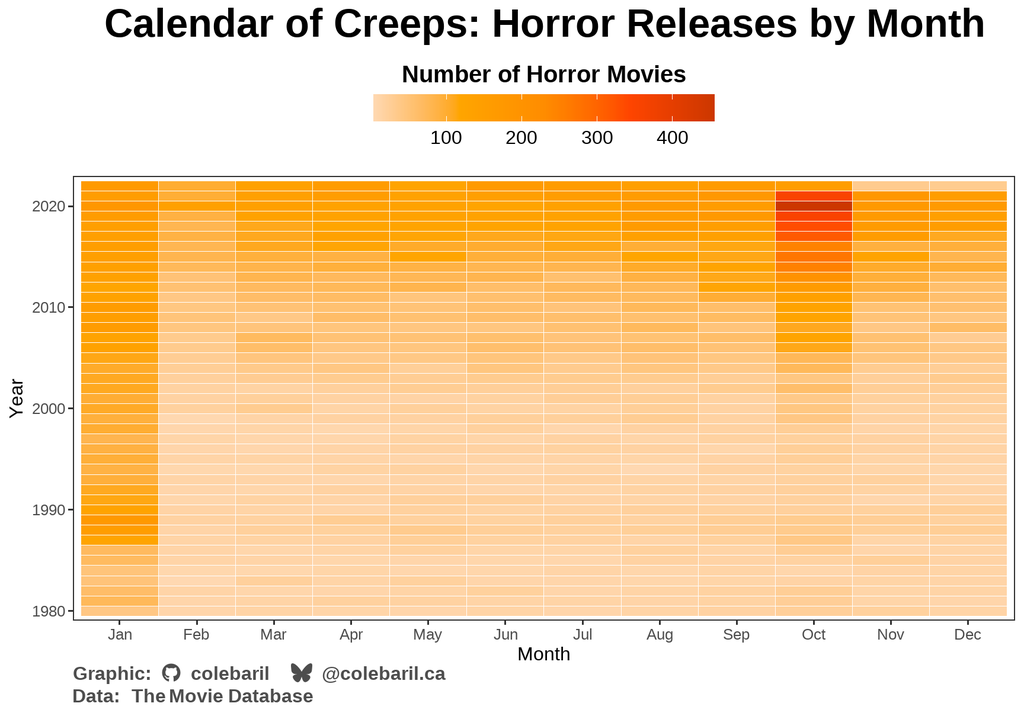

> As expected, there are more horror movie releases in October, particularly beginning in the 2000s. From 2010 to present, this trend is amplified. What I did not expect to find was a consistent number of horror movie releases in January. I learned that this trend is likely due to [Dump Months](https://en.wikipedia.org/wiki/Dump_months) in which movies that performed poorly at test screenings, movies with lesser known actors, or less popular genres (e.g., horror) are released. The rationale for this is primarily because audiences are lower and inconsistent in January and February compared to holiday months.

### **🎃 October 2: Horror Movie Title Word Cloud 🎃**

[interactive chart not shown]

### **🎃 October 3: Haunted Places 🎃**

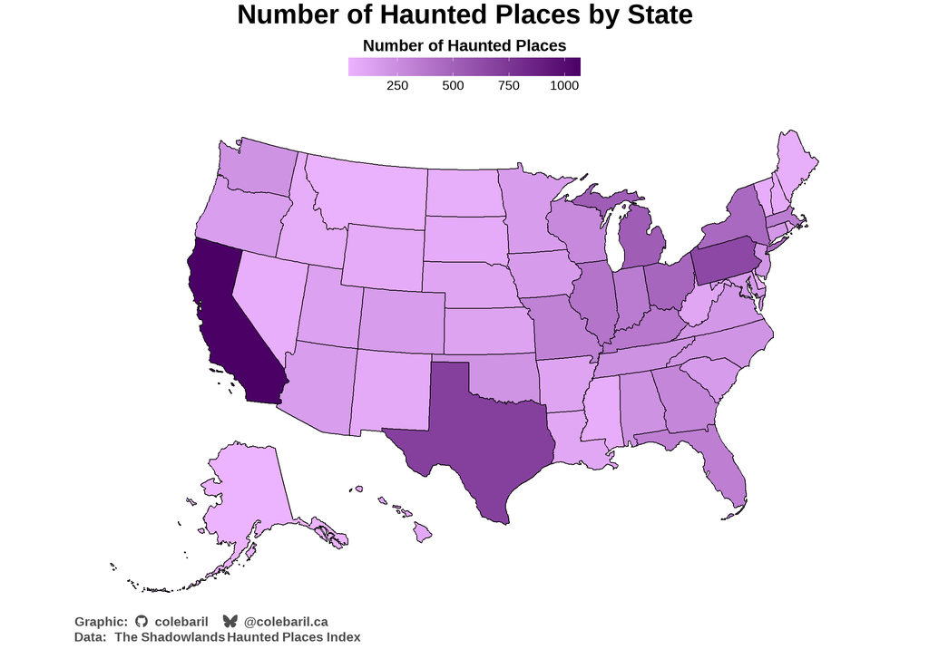

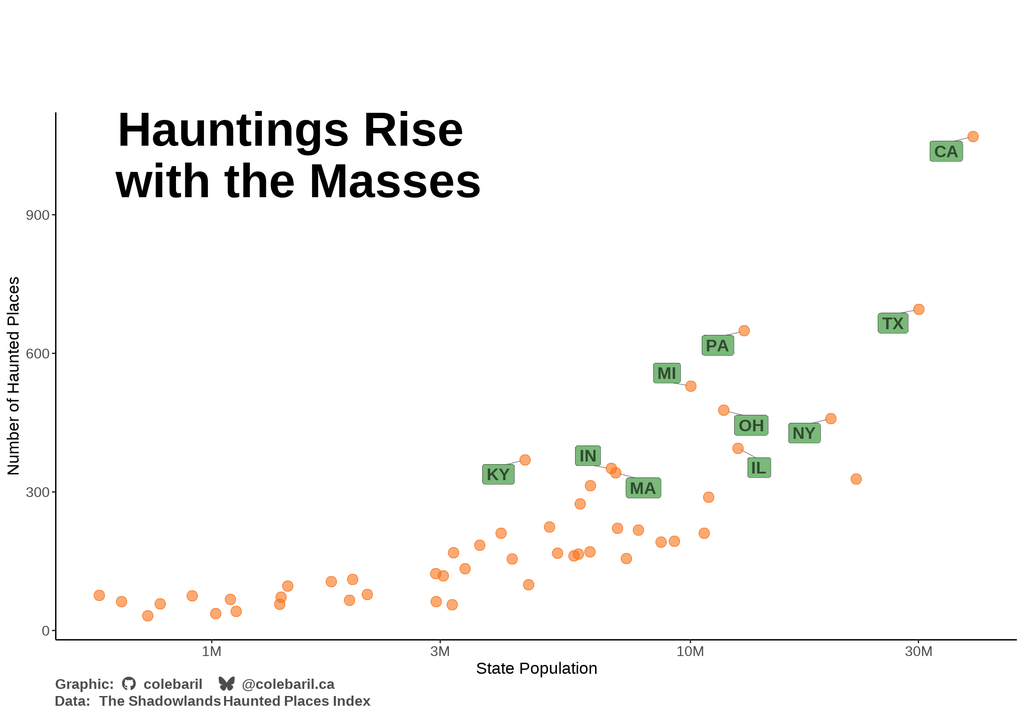

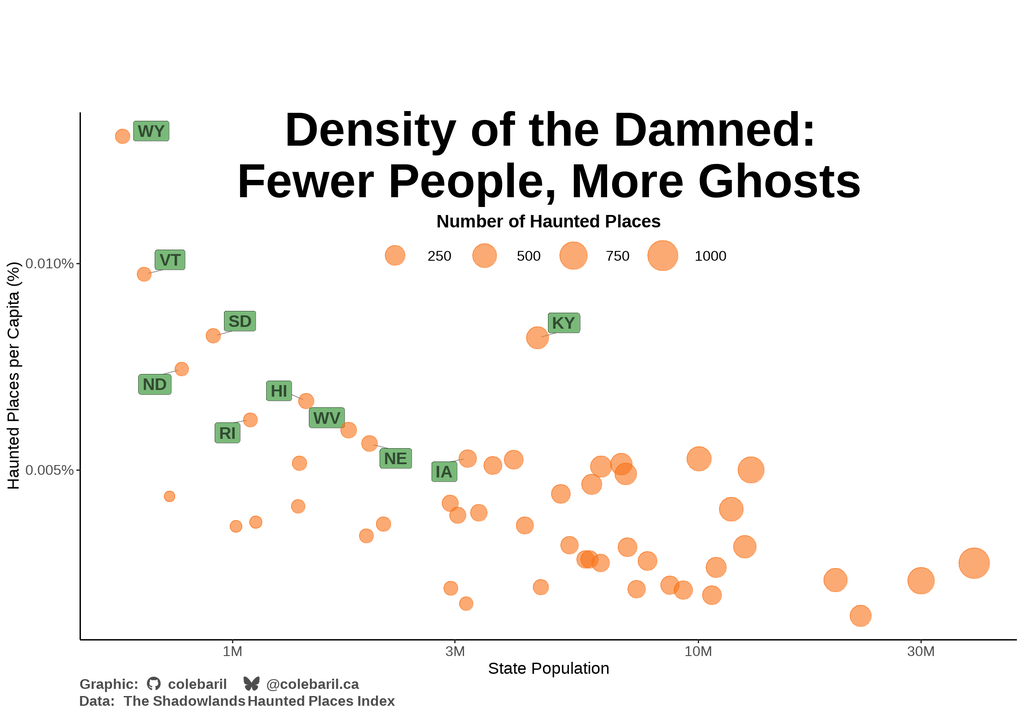

https://www.theshadowlands.net/places/

### **🎃 October 6: Spirit Halloween 🎃**

[figure not shown]